# Meat Protein Intake Across Countries: Confidence Interval Analysis

Sean Schilk

9/7/25

# 1 Introduction

This data set includes the percentage of protein intake from different types of food in countries around the world. The last couple of columns also includes counts of obesity and COVID-19 cases as percentages of the total population for comparison purposes. I will be working with the meat variable, which is the percentage of total protein intake in a country that comes from meat sources.

```r
library(knitr)
url="https://pengdsci.github.io/STA321/ww02/w02-Protein_Supply_Quantity_Data.csv"
protein = read.csv(url, header = TRUE)
var.name = names(protein)
kable(data.frame(var.name))
```

| var.name |
| --- |
| Country |
| AlcoholicBeverages |
| AnimalProducts |
| Animalfats |
| CerealsExcludingBeer |
| Eggs |
| FishSeafood |
| FruitsExcludingWine |
| Meat |
| MilkExcludingButter |
| Offals |
| Oilcrops |
| Pulses |
| Spices |
| StarchyRoots |
| Stimulants |
| Treenuts |
| VegetalProducts |
| VegetableOils |
| Vegetables |
| Miscellaneous |
| Obesity |
| Confirmed |
| Deaths |
| Recovered |
| Active |
| Population |

First let’s construct a confidence interval using methods learned in earlier courses

```r
t.test(protein$Meat)
```

```
    One Sample t-test

data:  protein$Meat
t = 27.536, df = 169, p-value < 2.2e-16
alternative hypothesis: true mean is not equal to 0
95 percent confidence interval:
  9.193009 10.612918
sample estimates:
mean of x
 9.902964
```

A confidence interval from t.test() gives a range of plausible values for the population mean. We are 95% confident that the true population mean lies between 9.19 and 10.61

Now let’s use the bootstrapping methods we learned in class.

```r
summary(protein$Meat)
```

```
   Min. 1st Qu.  Median    Mean 3rd Qu.    Max.
  1.018   5.957  10.213   9.903  13.325  21.625
```

```r
set.seed(1)
bt.sample.mean.vec = NULL
for(i in 1:1000){
  ith.bt.sample = sample(x = protein$Meat, # sample from single column
                       size = 170,
                    replace = TRUE
                       )
  bt.sample.mean.vec[i] = mean(ith.bt.sample)

}
```

```r
CI = quantile(bt.sample.mean.vec, c(0.025, 0.975))
CI
```

```
     2.5%     97.5%
 9.248011 10.594598
```

We are 95% confident that the true population mean lies between 9.25 and 10.59

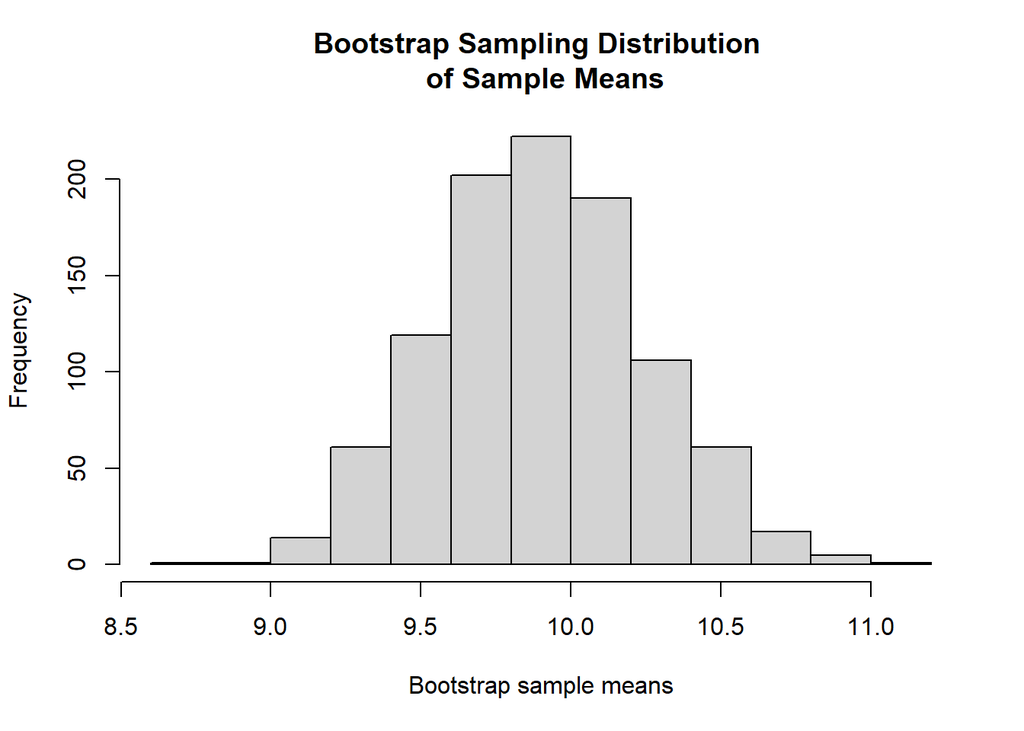

```r
hist(bt.sample.mean.vec,                     # data used for histogram
     breaks = 14,                            # specify number of vertical bars
       xlab = "Bootstrap sample means",      # change the label of x-axis
      # add a title to the histogram
        main="Bootstrap Sampling Distribution \n of Sample Means")
```

There is some slight variation in our methods, as the 95% CI does not cover the same range. The difference here is that our t-based CI used a theoretical formula using a t-dist to create the interval, while bootstrap CI used the empirical dist from a large amount of bootstrap resamples to create the CI.

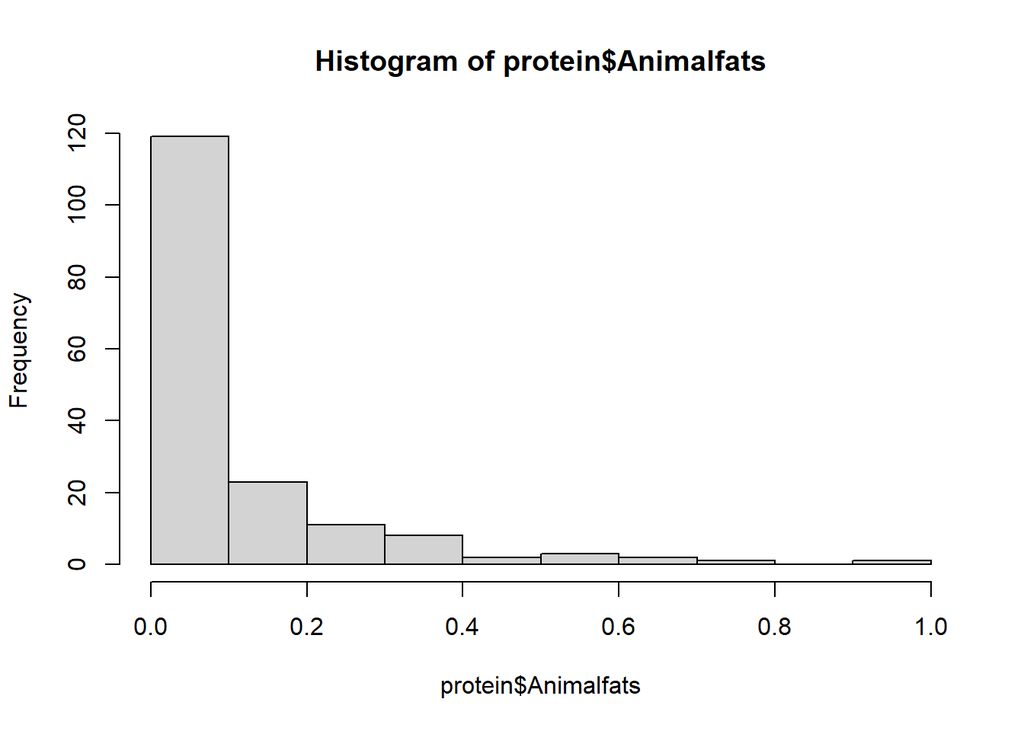

```r
hist(protein$Animalfats)
```